# BE 521: Homework 7 Questions

## P300 Speller

#### Spring 2024

34 points

### Due: March 21st, 2024

Objective: Spell letters using neurosignals.

```python
!jupyter nbconvert --to html YuanchaoZhang_HW7.ipynb
```

```
[NbConvertApp] Converting notebook YuanchaoZhang_HW7.ipynb to html
[NbConvertApp] Writing 1237316 bytes to YuanchaoZhang_HW7.html
```

```python
#Set up the notebook environment
!pip install git+https://github.com/ieeg-portal/ieegpy.git # Install ieegpy toolbox directly from github
!pip install mne

from ieeg.auth import Session
import matplotlib.pyplot as plt
from scipy.io import loadmat
import mne
import pandas as pd

standard_montage = mne.channels.make_standard_montage('standard_1005')
info = mne.create_info(['FC5', 'FC3', 'FC1', 'FCz', 'FC2', 'FC4', 'FC6', 'C5', 'C3', 'C1', 'Cz', 'C2', 'C4', 'C6', 'CP5', 'CP3', 'CP1', 'CPz', 'CP2', 'CP4', 'CP6', 'Fp1', 'Fpz', 'Fp2', 'AF7', 'AF3', 'AFz', 'AF4', 'AF8', 'F7', 'F5', 'F3', 'F1', 'Fz', 'F2', 'F4', 'F6', 'F8', 'FT7', 'FT8', 'T7', 'T8', 'T9', 'T10', 'TP7', 'TP8', 'P7', 'P5', 'P3', 'P1', 'Pz', 'P2', 'P4', 'P6', 'P8', 'PO7', 'PO3', 'POz', 'PO4', 'PO8', 'O1', 'Oz', 'O2', 'Iz'], 250, ch_types='eeg').set_montage(standard_montage)
```

```
  Cloning https://github.com/ieeg-portal/ieegpy.git to /tmp/pip-req-build-hhwcnufc
  Running command git clone --filter=blob:none --quiet https://github.com/ieeg-portal/ieegpy.git /tmp/pip-req-build-hhwcnufc
  Resolved https://github.com/ieeg-portal/ieegpy.git to commit 080bfa42a8503380ef164b5e7b116613f75073bb
  Preparing metadata (setup.py) ... done
```

## P300 Speller

In this homework, you will work with data from a P300-based brain computer interface called BCI2000 (Schalk et al. 2004) that allows people to spell words by focusing their attention on a particular letter displayed on the screen. In each trial the user focused on a letter, and when that letter's row or column is flashed, the user's brain elicits a P300 evoked response. By analyzing whether a P300 signal was produced across the flashes of many different rows or columns, the computer can determine the letter that the person is focusing on.

## Data Organization

The data for this homework is stored in `I521_A0008_D001` on the IEEG Portal.The EEG in this dataset were recorded during 85 intended letter spellings. For each letter spelling, 12 row/columns were flashed 15 times in random order ($12 \times 15 = 180$ iterations). The EEG was recorded with a sampling rate of 240 Hz on a 64-channel scalp EEG.  
The annotations for this dataset are organized in two layers as follows:

- `TargetLetter` annotation layer indicates the target letter (annotation.description) on which the user was focusing during the recorded EEG segment (annotation.start/annotation.stop). This layer is also provided as TargetLetterAnnots.mat.
- `Stim` annotation layer indicates the row/column that is being flashed (annotation.description) and whether the target letter is contained in that flash (annotation.type). The recorded EEG during that flash is (annotation.start/annotation.stop). Note that this annotation layer is provided as StimAnnots.mat. It is NOT on the portal.

We provide the annotation layers as CSV files and provide some code that loads, previews, and iterates through the rows of the files with the information above.

```python
# load stim annotations file
stim_annots = pd.read_csv("StimAnnots.csv")
# preview dataframe with stim annotations
display(stim_annots.head())
# iterate through rows of dataframe
for index, row in stim_annots.iterrows():
  print(row.description, row.start, row.stop)
  if index == 1:
    break
```

|  | type | description | start | stop |
| --- | --- | --- | --- | --- |
| 0 | 0 | 12 | 1 | 1000000 |
| 1 | 0 | 11 | 1000001 | 2000000 |
| 2 | 0 | 3 | 2000001 | 3000000 |
| 3 | 0 | 10 | 3000001 | 4000000 |
| 4 | 0 | 9 | 4000001 | 5000000 |

```
12 1 1000000
11 1000001 2000000
```

## 1. Exploring the data

In this section you will explore some basic properties of the data in `I521_A0008_D001`. We suggest using the `load_full_channels` function to load in all of the channels and saving the data (will take ~3 minutes), since loading each channel independently will take a long time.

```python
import numpy as np
```

```python
def load_full_channels(dataset, duration_secs, sampling_rate, chn_idx):
  """
  Loads the entire channel from IEEG.org
  Input:
    dataset: the IEEG dataset object
    duration_secs: the duration of the channel, in seconds
    sampling_rate: the sampling rate of the channel, in Hz
    chn_idx: the indicies of the m channels you want to load, as an array-like object
  Returns:
    [n, m] numpy array of the channels' values.
  """
  #stores the segments of the channel's data
  chn_segments = []

  #how many segments do we expect?
  num_segments = int(np.ceil(duration_secs * sampling_rate / 6e4))

  #segment start times and the step
  seg_start, step = np.linspace(1, duration_secs*1e6, num_segments, endpoint=False, retstep=True)

  #get the segments
  for start in seg_start:
    chn_segments.append(dataset.get_data(start, step, chn_idx))

  #concatenate the segments vertically
  return np.vstack(chn_segments)
```

```python
with open('/content/Yua_ieeglogin.bin', 'r') as f:
  session = Session('Yuanchz1118', f.read())

# get the specified dataset from IEEG
dataset = session.open_dataset('I521_A0008_D001')

label = dataset.get_channel_labels()
index = dataset.get_channel_indices(label)
print("List of Channel Numbers:\n", index)
```

```
List of Channel Numbers:
 [0, 1, 2, 3, 4, 5, 6, 7, 8, 9, 10, 11, 12, 13, 14, 15, 16, 17, 18, 19, 20, 21, 22, 23, 24, 25, 26, 27, 28, 29, 30, 31, 32, 33, 34, 35, 36, 37, 38, 39, 40, 41, 42, 43, 44, 45, 46, 47, 48, 49, 50, 51, 52, 53, 54, 55, 56, 57, 58, 59, 60, 61, 62, 63]
```

```python
first_timeseries = dataset.get_time_series_details(label[0])
sample_rate = int(first_timeseries.sample_rate)
duration = first_timeseries.duration
# first_channel = load_full_channels(dataset, first_duration / 10**6, first_sample_rate, [0])
# print(first_channel)

'''each_channel_lst = []
for i in index:
  each_timeseries = dataset.get_time_series_details(label[i])
  each_sample_rate = int(each_timeseries.sample_rate)
  each_duration = each_timeseries.duration
  each_channel = load_full_channels(dataset, each_duration / 10**6, each_sample_rate, [i])
  each_channel_lst.append(each_channel)
print(each_channel_lst)'''

### Saving time by loading in all of the channels and saving the data
full_data = load_full_channels(dataset, duration / 10**6, sample_rate, index)
print("Full Data in All Channels:\n", full_data)
```

```
Full Data in All Channels:
 [[  0.08  -17.93   -9.266 ... -19.443 -10.342 -14.575]
 [ -2.247 -17.676  -6.459 ... -17.911  -8.022 -13.052]
 [  7.583 -14.875  -3.397 ... -14.083  -4.156  -9.753]
 ...
 [ 11.723 -15.894 -28.406 ...  15.008  30.383   5.725]
 [ 11.723 -16.148 -29.938 ...  17.305  28.836   6.232]
 [ 12.24  -16.403 -31.979 ...  15.008  24.97    4.456]]
```

### 1

For channel 10 (Cz), plot the mean EEG for the target and non-target stimuli separately, (i.e. rows/columns including and not-including the desired character, respectively), on the same set of axes. Label your x-axis in milliseconds. (3 pts)

```python
def load_annotations(dataset, annotation_layer_name):
  """
  Loads annotations for the specified annotation layer
  Input: 2 arguments
    dataset: the IEEG Dataset object
    annotation_layer_name: the name of the annotation layer (str)
  Returns: 2 objects
    (n x 3) numpy array. [i, :] contains the description, start_time_offset_usec, and end_time_offset_usec of annotation i, respectively.
    n-sized list. The raw output of the IEEG .get_annotations() function
  """
  #load the annotations
  annotations = dataset.get_annotations(annotation_layer_name)

  #container for annotation information. Set all default values to -1.
  anno_info = np.zeros((len(annotations), 3)) - 1

  #for each annotation, get the description, start and end times
  for i in range(len(annotations)):
    anno_info[i, 0] = annotations[i].description
    anno_info[i, 1] = annotations[i].start_time_offset_usec
    anno_info[i, 2] = annotations[i].end_time_offset_usec

  return [anno_info, annotations]
```

```python
### Test Set: label[0]
### Training Set: label[1]
# layers = dataset.get_annotation_layers()
# print(layers)
print(stim_annots)

### Get annotations from the training set depending on the certain layer
### Type = 0: Non-Targeted ; Type = 1: Targeted
stim_type = stim_annots.type
print("Type = 0: Non-Target ; Type = 1: Target \n", stim_type)
# print(stim_type[15296])
print(len(stim_type))

### For channel 10 (Cz):
Cz_timeseries = dataset.get_time_series_details(label[10])
# print("TimeSeries of the Cz Channel:", Cz_timeseries)
sample_rate = int(Cz_timeseries.sample_rate)
# print("Sample Rate of the Cz Channel:", sample_rate, "Hz")
# duration = Cz_timeseries.duration
# print("Duration of the Cz Channel:", duration, "us")
Cz_channel = load_full_channels(dataset, duration / 10**6, sample_rate, [10])
print("Channel Data of the Cz Channel(μV):\n", Cz_channel)
print(len(Cz_channel))
# nan_count = np.sum(np.isnan(Cz_channel))
# print(nan_count)
# print(Cz_channel[3672006])
```

```
       type  description        start         stop
0         0           12            1      1000000
1         0           11      1000001      2000000
2         0            3      2000001      3000000
3         0           10      3000001      4000000
4         0            9      4000001      5000000
...     ...          ...          ...          ...
15295     0            2  15295000001  15296000000
15296     1            3  15296000001  15297000000
15297     0           12  15297000001  15298000000
15298     1            8  15298000001  15299000000
15299     0            7  15299000001  15300000000

[15300 rows x 4 columns]
Type = 0: Non-Target ; Type = 1: Target
 0        0
1        0
2        0
3        0
4        0
        ..
15295    0
15296    1
15297    0
15298    1
15299    0
Name: type, Length: 15300, dtype: int64
15300
Channel Data of the Cz Channel(μV):
 [[ -5.139]
 [ -1.541]
 [  1.027]
 ...
 [ -9.25 ]
 [-11.306]
 [-14.389]]
3672012
```

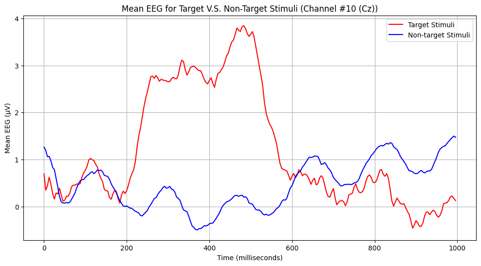

```python
# My code here
### Type = 0: Non-Targeted ; Type = 1: Targeted
start_time = Cz_timeseries.start_time / 10**3
# print(start_time)

# print(len(stim_type))
### range [-136762-192892] in 3672000 samples
split_Cz = np.split(Cz_channel[:3672000], len(stim_type))
# print(len(split_Cz))
duration_ms = duration / 10**3

Cz_Non_Matrix = np.zeros((sample_rate , 1))
Cz_Target_Matrix = np.zeros((sample_rate, 1))

for i in range(len(stim_type)):
  tmp_Cz = split_Cz[i]
  # print(tmp_Cz)

  if stim_type[i] == 0:
    Cz_Non_Matrix = np.concatenate((Cz_Non_Matrix, tmp_Cz), axis=1)

  elif stim_type[i] == 1:
    Cz_Target_Matrix = np.concatenate((Cz_Target_Matrix, tmp_Cz), axis=1)

Cz_Non_Mean = np.mean(Cz_Non_Matrix, axis = 1)
# print(Cz_Non_Mean)
Cz_Target_Mean = np.mean(Cz_Target_Matrix, axis = 1)
# print(Cz_Target_Mean)

# print(duration_ms)
### Duration of each stimuli = 1000000 ms = 1000s
Step_Non = 1000 / len(Cz_Non_Mean)
# print(Step_Non)
non_time_lst = np.arange(start_time, 1000, Step_Non)
Step_Target = 1000 / len(Cz_Target_Mean)
target_time_lst = np.arange(start_time, 1000, Step_Target)

# Plotting
plt.figure(figsize=(12, 6))
plt.plot(target_time_lst, Cz_Target_Mean, label = 'Target Stimuli', color='red')
plt.plot(non_time_lst, Cz_Non_Mean, label = 'Non-target Stimuli', color='blue')
plt.xlabel('Time (milliseconds)')
plt.ylabel('Mean EEG (μV)')
plt.title('Mean EEG for Target V.S. Non-Target Stimuli (Channel #10 (Cz))')
plt.legend()
plt.grid(True)
plt.show()
```

### 2

Repeat the previous questions for channel 41 (T8). (1 pts)

```python
# My code here
### For channel 41 (T8):
T8_channel = load_full_channels(dataset, duration / 10**6, sample_rate, [41])
# T8_channel = dataset.get_data(1, duration + 1,[41])
print("Channel Data of the 41st Channel(μV):\n",  T8_channel)
print(len(T8_channel))
# nan_count = np.sum(np.isnan(Cz_channel))
# print(nan_count)
# print(Cz_channel[3672006])
```

```
Channel Data of the 41st Channel(μV):
 [[-11.486]
 [ -8.666]
 [ -4.309]
 ...
 [-20.201]
 [-18.663]
 [-19.432]]
3672012
```

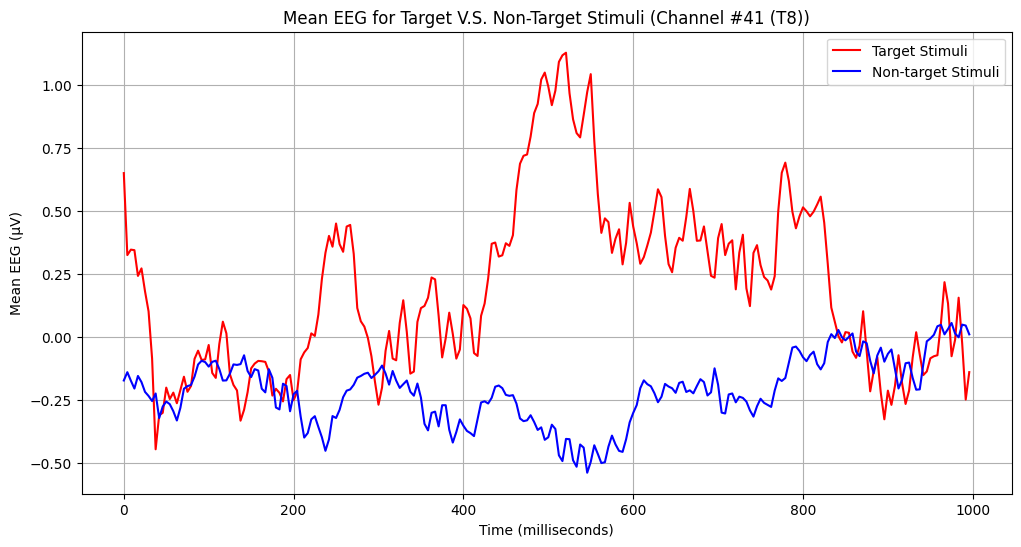

```python
# My code here
### Type = 0: Non-Targeted ; Type = 1: Targeted

### range [-136762-192892] in 3672000 samples
split_T8 = np.split(T8_channel[:3672000], len(stim_type))
# print(len(split_Cz))
duration_ms = duration / 10**3

T8_Non_Matrix = np.zeros((sample_rate , 1))
T8_Target_Matrix = np.zeros((sample_rate, 1))

for i in range(len(stim_type)):
  tmp_T8 = split_T8[i]
  # print(tmp_Cz)

  if stim_type[i] == 0:
    T8_Non_Matrix = np.concatenate((T8_Non_Matrix, tmp_T8), axis=1)

  elif stim_type[i] == 1:
    T8_Target_Matrix = np.concatenate((T8_Target_Matrix, tmp_T8), axis=1)

T8_Non_Mean = np.mean(T8_Non_Matrix, axis = 1)
# print(Cz_Non_Mean)
T8_Target_Mean = np.mean(T8_Target_Matrix, axis = 1)
# print(Cz_Target_Mean)

# Plotting
plt.figure(figsize=(12, 6))
plt.plot(target_time_lst, T8_Target_Mean, label = 'Target Stimuli', color='red')
plt.plot(non_time_lst, T8_Non_Mean, label = 'Non-target Stimuli', color='blue')
plt.xlabel('Time (milliseconds)')
plt.ylabel('Mean EEG (μV)')
plt.title('Mean EEG for Target V.S. Non-Target Stimuli (Channel #41 (T8))')
plt.legend()
plt.grid(True)
plt.show()
```

### 3

Which of the two previous channels looks best for distinguishing between target and non-target stimuli? Which time points look best? Explain in a few sentences. (2 pts)

**My Answer Here:**

**Channel #10 (Cz)** looks best for distinguishing between target and non-target stimuli.

Time points from **300 to 500 (milliseconds)** looks best.

### 4

Compute the mean difference between the target and non-target stimuli for each channel at timepoint 300 ms averaged across all row/column flashes. Visualize these values using [`mne.viz.plot_topomap`](https://mne.tools/dev/generated/mne.viz.plot_topomap.html) and the example code given below by replacing the argument `your_data_here`. (3 pts)

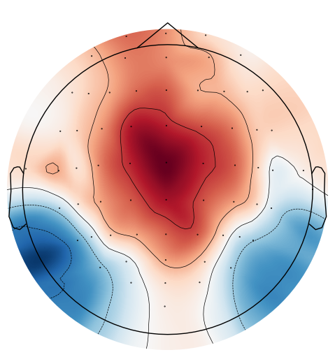

```python
# My code here
timepoint_index = int(300 / (1000 / sample_rate))
split_each_lst = []

for i in range(len(index)):
  # print(full_data[:,i][:3672000])
  split_each = np.split(full_data[:,i][:3672000], len(stim_type))
  # print(len(split_each))
  split_each_lst.append(split_each)
  # print(len(split_each_lst))

mean_diff_lst = []

for m in range(len(split_each_lst)):
  Each_Non_Lst = []
  Each_Target_Lst = []
  for j in range(len(stim_type)):
    # print(m)
    # print(split_each_lst[m][j])
    tmp_each = split_each_lst[m][j][timepoint_index]
    # print(tmp_each.shape)
    # print(tmp_each)

    if stim_type[j] == 0:
      # Each_Non_Matrix = np.concatenate((Each_Non_Matrix, tmp_each), axis=1)
      Each_Non_Lst.append(tmp_each)

    elif stim_type[j] == 1:
      # Each_Target_Matrix = np.concatenate((Each_Target_Matrix, tmp_each), axis=1)
      Each_Target_Lst.append(tmp_each)

  Each_Non_Mean = np.mean(Each_Non_Lst)
  Each_Target_Mean = np.mean(Each_Target_Lst)
  tmp_mean_diff = Each_Target_Mean - Each_Non_Mean
  mean_diff_lst.append(tmp_mean_diff)

mne.viz.plot_topomap(mean_diff_lst, info, size = 5)
```

### 5

How do the red and blue parts of this plot correspond to the plots from above? (2 pts)

**My Answer Here:**

**Red parts** of this plot correspond to the plot of "Mean EEG for Target V.S. Non-Target Stimuli **(Channel #10 (Cz))**".

**Blue parts** of this plot correspond to the plot of "Mean EEG for Target V.S. Non-Target Stimuli **(Channel #41 (T8))**".

In the red part, channels have much greater difference between certain pair of Target and Non-Target data than other channels in the blue part. And I tend to say that Cz Channel should nearly in the center of red part, because it provides the most strong evidences for my future analysis!

## 2. Using individual P300s in prediction

### 1

Explain a potential advantage to using just one channel other than the obvious speed of calculation advantage. Explain one disadvantage. (3 pts)

**My Answer Here:**

**One Potential Advantage:**

**Decreased Sensitivity to Noise and Artifacts:** In situations where noise or artifacts impair the EEG data quality, using a single channel may be beneficial. In multi-channel recordings, noise sources such as electrical interference, eye blinks, and muscle movements may have varying effects on each channel.

**One Potential Disadvantage:**

**Restricted Comprehensive Information:** Only using one channel among multiple channels may decrease the precision and dependability of the P300 activity prediction; it could be less representative with considerable biases, especially if the selected channel is better at capturing the desired signal or if artifacts interfere with that specific channel.

### 2

One simple way of identifying a P300 in a single trial (which we'll call the *p300 score*) is to take the mean EEG from 250 to 450 ms and then subtract from it the mean EEG from 600 to 800 ms. What is the *p300 score* for epoch (letter) 9, iteration 10 at electrode Cz? (3 pts)

```python
# load TargetLetter annotations file
target_annots = pd.read_csv("TargetLetterAnnots.csv")
# preview dataframe with stim annotations
display(target_annots.head())
# iterate through rows of dataframe
for index, row in target_annots.iterrows():
  print(row.description, row.start, row.stop)
  if index == 1:
    break
```

|  | type | description | start | stop |
| --- | --- | --- | --- | --- |
| 0 | Target Letter | E | 1 | 180000000 |
| 1 | Target Letter | A | 180000001 | 360000000 |
| 2 | Target Letter | E | 360000001 | 540000000 |
| 3 | Target Letter | V | 540000001 | 720000000 |
| 4 | Target Letter | Q | 720000001 | 900000000 |

```
E 1 180000000
A 180000001 360000000
```

```python
### Epochs: 85, Iterations: 180
print(target_annots.shape)
print(target_annots)
# print(target_annots.description)

### Epoch(Letter) 9: J
Nine_Epoch = target_annots.description[8]
print("Epoch(Letter) #9:", Nine_Epoch)
Nine_Epoch_Start = target_annots.start[8]
print(Nine_Epoch_Start)
Nine_Epoch_End = target_annots.stop[8]
print(Nine_Epoch_End)

### Extract EEG signal for epoch 9, iteration 10, and electrode Cz
# stim_iteration = stim_type[1440:1621]
# print(stim_iteration)
```

```
(85, 4)
             type description        start         stop
0   Target Letter           E            1    180000000
1   Target Letter           A    180000001    360000000
2   Target Letter           E    360000001    540000000
3   Target Letter           V    540000001    720000000
4   Target Letter           Q    720000001    900000000
..            ...         ...          ...          ...
80  Target Letter           O  14400000001  14580000000
81  Target Letter           T  14580000001  14760000000
82  Target Letter           H  14760000001  14940000000
83  Target Letter           Q  14940000001  15120000000
84  Target Letter           I  15120000001  15300000000

[85 rows x 4 columns]
Epoch(Letter) #9: J
1440000001
1620000000
```

```python
# My code here
### Define the timepoints corresponding to 250 ms and 450 ms
time_250ms_sec = 250 / 10**3  # 250 ms = 0.25 sec
time_450ms_sec = 450 / 10**3  # 450 ms = 0.45 sec

### Define the timepoints corresponding to 600 ms and 800 ms
time_600ms_sec = 600 / 10**3   # 600 ms = 0.6 sec
time_800ms_sec = 800 / 10**3  # 800 ms = 0.8 sec

### Calculate the corresponding indices in the EEG data array
index_250ms = int(time_250ms_sec * sample_rate)
index_450ms = int(time_450ms_sec * sample_rate)
index_600ms = int(time_600ms_sec * sample_rate)
index_800ms = int(time_800ms_sec * sample_rate)

### (180 * 8) = 1440 Epochs + 9 Iteration(Find 10th Iteration)
Cz_250ms_450ms = split_Cz[180 * 8 + 9][index_250ms:index_450ms]
Cz_600ms_800ms = split_Cz[180 * 8 + 9][index_600ms:index_800ms]

Cz_250ms_450ms_Mean = np.mean(Cz_250ms_450ms)
Cz_600ms_800ms_Mean = np.mean(Cz_600ms_800ms)
p300_score = Cz_250ms_450ms_Mean - Cz_600ms_800ms_Mean

print("P300 score for epoch 9, iteration 10, at electrode Cz:", p300_score)
```

```
P300 score for epoch 9, iteration 10, at electrode Cz: -4.518291666666666
```

**My Answer Here:**

P300 score for epoch 9, iteration 10, at electrode Cz: **-4.518291666666666**

### 3

Plot the p300 scores for each row/column in epoch 26 at electrode Cz. (3 pts)

```python
### Epoch(Letter) 26: D
Epoch_26th = target_annots.description[25]
print("Epoch(Letter) #26:", Epoch_26th)
Epoch_Start_26th = target_annots.start[25]
print(Epoch_Start_26th)
Epoch_End_26th = target_annots.stop[25]
print(Epoch_End_26th)
```

```
Epoch(Letter) #26: D
4500000001
4680000000
```

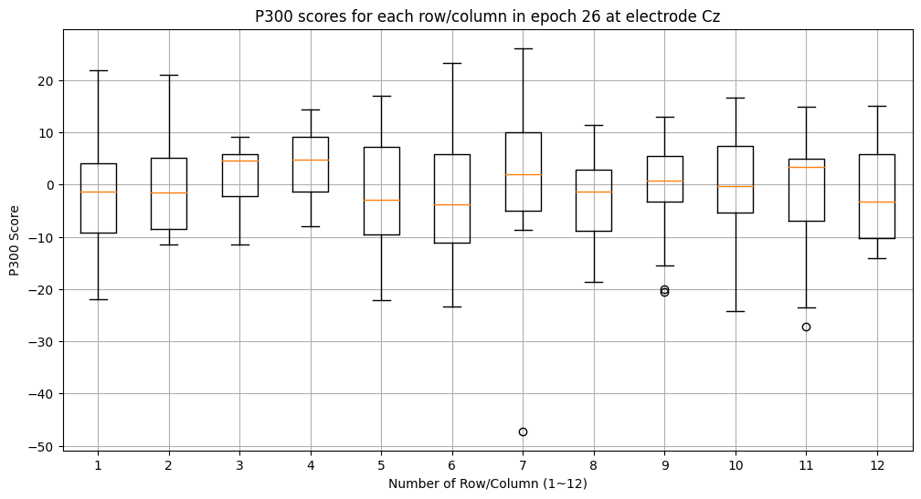

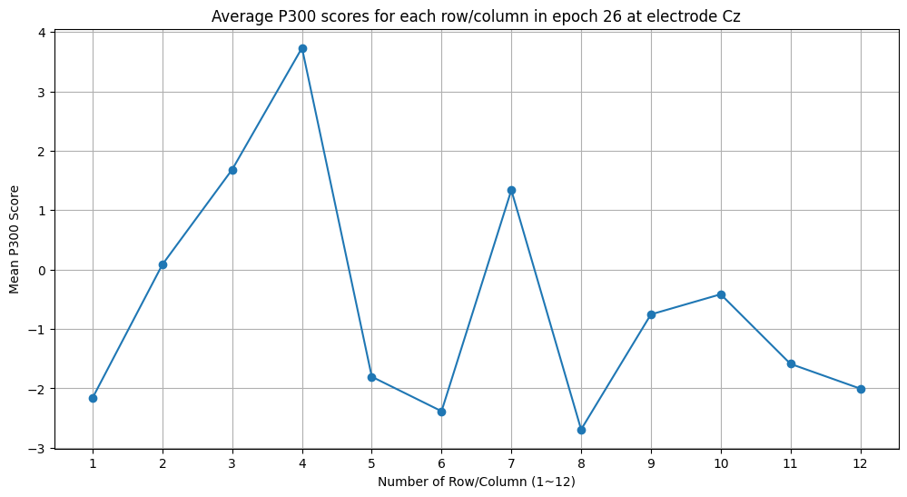

```python
# My code here
### (180 * 25) = 4500 Epochs, (180 * 26) = 4680
# print(Cz_channel[4500:4680])
# stim26_RowCol = stim_annots.description[4500:4680]
# print(stim26_RowCol)

### This function is used to extract p300 scores for each row/column in each epoch at electrode Cz
def extract_p300_score(start_time_secs, end_time_secs):

  p300_score_lst1 = []
  p300_score_lst2 = []
  p300_score_lst3 = []
  p300_score_lst4 = []
  p300_score_lst5 = []
  p300_score_lst6 = []
  p300_score_lst7 = []
  p300_score_lst8 = []
  p300_score_lst9 = []
  p300_score_lst10 = []
  p300_score_lst11 = []
  p300_score_lst12 = []

  Combine_p300_score_lst = []
  Combine_p300_mean_score_lst = []

  stim_RowCol = stim_annots.description[start_time_secs:end_time_secs]

  for i in range(start_time_secs, end_time_secs):

    Cz_250ms_450ms2 = split_Cz[i][index_250ms:index_450ms]
    # print(Cz_250ms_450ms2)
    Cz_600ms_800ms2 = split_Cz[i][index_600ms:index_800ms]
    Cz_250ms_450ms_Mean2 = np.mean(Cz_250ms_450ms2)
    Cz_600ms_800ms_Mean2 = np.mean(Cz_600ms_800ms2)

    p300_score2 = Cz_250ms_450ms_Mean2 - Cz_600ms_800ms_Mean2

    # print(stim_RowCol[i])
    if stim_RowCol[i] == 1:
      p300_score_lst1.append(p300_score2)
    if stim_RowCol[i] == 2:
      p300_score_lst2.append(p300_score2)
    if stim_RowCol[i] == 3:
      p300_score_lst3.append(p300_score2)
    if stim_RowCol[i] == 4:
      p300_score_lst4.append(p300_score2)
    if stim_RowCol[i] == 5:
      p300_score_lst5.append(p300_score2)
    if stim_RowCol[i] == 6:
      p300_score_lst6.append(p300_score2)
    if stim_RowCol[i] == 7:
      p300_score_lst7.append(p300_score2)
    if stim_RowCol[i] == 8:
      p300_score_lst8.append(p300_score2)
    if stim_RowCol[i] == 9:
      p300_score_lst9.append(p300_score2)
    if stim_RowCol[i] == 10:
      p300_score_lst10.append(p300_score2)
    if stim_RowCol[i] == 11:
      p300_score_lst11.append(p300_score2)
    if stim_RowCol[i] == 12:
      p300_score_lst12.append(p300_score2)

  Combine_p300_score_lst.append(p300_score_lst1)
  Combine_p300_score_lst.append(p300_score_lst2)
  Combine_p300_score_lst.append(p300_score_lst3)
  Combine_p300_score_lst.append(p300_score_lst4)
  Combine_p300_score_lst.append(p300_score_lst5)
  Combine_p300_score_lst.append(p300_score_lst6)
  Combine_p300_score_lst.append(p300_score_lst7)
  Combine_p300_score_lst.append(p300_score_lst8)
  Combine_p300_score_lst.append(p300_score_lst9)
  Combine_p300_score_lst.append(p300_score_lst10)
  Combine_p300_score_lst.append(p300_score_lst11)
  Combine_p300_score_lst.append(p300_score_lst12)

  p300_score_lst1_mean = np.mean(p300_score_lst1)
  # print(p300_score_lst1_mean)
  p300_score_lst2_mean = np.mean(p300_score_lst2)
  # print(p300_score_lst2_mean)
  p300_score_lst3_mean = np.mean(p300_score_lst3)
  p300_score_lst4_mean = np.mean(p300_score_lst4)
  p300_score_lst5_mean = np.mean(p300_score_lst5)
  p300_score_lst6_mean = np.mean(p300_score_lst6)
  p300_score_lst7_mean = np.mean(p300_score_lst7)
  p300_score_lst8_mean = np.mean(p300_score_lst8)
  p300_score_lst9_mean = np.mean(p300_score_lst9)
  p300_score_lst10_mean = np.mean(p300_score_lst10)
  p300_score_lst11_mean = np.mean(p300_score_lst11)
  p300_score_lst12_mean = np.mean(p300_score_lst12)

  Combine_p300_mean_score_lst.append(p300_score_lst1_mean)
  Combine_p300_mean_score_lst.append(p300_score_lst2_mean)
  Combine_p300_mean_score_lst.append(p300_score_lst3_mean)
  Combine_p300_mean_score_lst.append(p300_score_lst4_mean)
  Combine_p300_mean_score_lst.append(p300_score_lst5_mean)
  Combine_p300_mean_score_lst.append(p300_score_lst6_mean)
  Combine_p300_mean_score_lst.append(p300_score_lst7_mean)
  Combine_p300_mean_score_lst.append(p300_score_lst8_mean)
  Combine_p300_mean_score_lst.append(p300_score_lst9_mean)
  Combine_p300_mean_score_lst.append(p300_score_lst10_mean)
  Combine_p300_mean_score_lst.append(p300_score_lst11_mean)
  Combine_p300_mean_score_lst.append(p300_score_lst12_mean)

  return Combine_p300_score_lst, Combine_p300_mean_score_lst

### Extract p300 scores for each row/column in epoch #26 at electrode Cz
### (180 * 25) = 4500 Epochs, (180 * 26) = 4680
Combine_p300_score_lst1, Combine_p300_mean_score_lst1 = extract_p300_score(4500, 4680)

plt.figure(figsize=(12, 6))
plt.boxplot(Combine_p300_score_lst1)
plt.xlabel('Number of Row/Column (1~12)')
plt.ylabel('P300 Score')
plt.title('P300 scores for each row/column in epoch 26 at electrode Cz')
plt.grid(True)
plt.show()

print("\n\n")

plt.figure(figsize=(12, 6))
row_col = np.arange(1, 13, 1)
plt.plot(row_col, Combine_p300_mean_score_lst1,'-o')
plt.xlabel('Number of Row/Column (1~12)')
plt.xticks(row_col)
plt.ylabel('Mean P300 Score')
plt.title('Average P300 scores for each row/column in epoch 26 at electrode Cz')
plt.grid(True)
plt.show()
```

### 4

Based on your previous answer for epoch 26, what letter do you predict the person saw? Is this prediction correct? Note: Use the HW7_P300_speller.png file. The numbers correspond to the stim (2 pts)

```python
### Epoch(Letter) 26: D
### Number of Row/Column = (4,7) is corresponding to D
print("Predicted Epoch(Letter) #26:", 'D')
Epoch_26th = target_annots.description[25]
print("True Epoch(Letter) #26:", Epoch_26th)
```

```
Predicted Epoch(Letter) #26: D
True Epoch(Letter) #26: D
```

**My Answer Here:**

Because HW7_P300_speller.png file shows that I should match a pair of Row and Column to its corresponding Epoch(Letter), thus I consider 12 Rows/Columns as two parts:

**(1)** From Number of Row/Column 1~6: I assume they all belong to Columns.

**(2)** From Number of Row/Column 7~12: I assume they all belong to Rows.

Based on my previous P300 scores for each row/column in epoch 26 at electrode Cz, I notice the **Highest Mean P300 Score** is corresponding to **(1) the Number of Column: 4, (2) the Number of Row: 7**, and then **such a pair of Row's and Column's insection(4,7)** should be related to letter **'D'** based on HW7_P300_speller.png file.

**Therefore, I predict letter 'D' as the person saw. Because my prediction matches True Epoch(Letter) #26: D, I consider my prediction is correct.**

### 5

Using this p300 score, predict (and print out) the letter viewed at every epoch. What was you prediction accuracy? (2 pts)

```python
### True Epoch(Letters)
full_epoch = target_annots.description
print(full_epoch)
# target_annots.start
# target_annots.stop
```

```
0     E
1     A
2     E
3     V
4     Q
     ..
80    O
81    T
82    H
83    Q
84    I
Name: description, Length: 85, dtype: object
```

```python
# My code here
# print(split_Cz[0])
# print(extract_p300_score(180,360))
# print(extract_p300_score(4500, 4680))

### Compare Every Epoch(Letter)(True V.S. Pred)
True_Epoch_Lst = []
Pred_Epoch_Lst = []

for i in range(len(target_annots)):
  True_Epoch = target_annots.description[i]
  True_Epoch_Lst.append(True_Epoch)

  tmp_start_time = int(target_annots.start[i] / 10**6)
  # print(tmp_start_time)
  tmp_end_time = int(target_annots.stop[i] / 10**6)
  # print(tmp_end_time)

  _, tmp_p300_score = extract_p300_score(tmp_start_time, tmp_end_time)

  # print(tmp_p300_score)
  highest1_p300 = np.argmax(tmp_p300_score[:6]) + 1
  # print(highest1_p300)
  highest2_p300 = np.argmax(tmp_p300_score[6:12]) + 7
  # print(highest2_p300)
  two_highest_p300 = [highest1_p300, highest2_p300]
  # print(two_highest_p300)

  ### Column:1 in P300_Speller with six rows:7 ~ 12
  if two_highest_p300 == [1,7]:
    Pred_Epoch = 'A'
  if two_highest_p300 == [1,8]:
    Pred_Epoch = 'G'
  if two_highest_p300 == [1,9]:
    Pred_Epoch = 'M'
  if two_highest_p300 == [1,10]:
    Pred_Epoch = 'S'
  if two_highest_p300 == [12,9]:
    Pred_Epoch = 'Y'
  if two_highest_p300 == [1,12]:
    Pred_Epoch = '5'

  ### Column:2 in P300_Speller with six rows:7 ~ 12
  if two_highest_p300 == [2,7]:
    Pred_Epoch = 'B'
  if two_highest_p300 == [2,8]:
    Pred_Epoch = 'H'
  if two_highest_p300 == [2,9]:
    Pred_Epoch = 'N'
  if two_highest_p300 == [2,10]:
    Pred_Epoch = 'T'
  if two_highest_p300 == [2,11]:
    Pred_Epoch = 'Z'
  if two_highest_p300 == [2,12]:
    Pred_Epoch = '6'

  ### Column:3 in P300_Speller with six rows:7 ~ 12
  if two_highest_p300 == [3,7]:
    Pred_Epoch = 'C'
  if two_highest_p300 == [3,8]:
    Pred_Epoch = 'I'
  if two_highest_p300 == [3,9]:
    Pred_Epoch = 'O'
  if two_highest_p300 == [3,10]:
    Pred_Epoch = 'U'
  if two_highest_p300 == [3,11]:
    Pred_Epoch = '1'
  if two_highest_p300 == [3,12]:
    Pred_Epoch = '7'

  ### Column:4 in P300_Speller with six rows:7 ~ 12
  if two_highest_p300 == [4,7]:
    Pred_Epoch = 'D'
  if two_highest_p300 == [4,8]:
    Pred_Epoch = 'J'
  if two_highest_p300 == [4,9]:
    Pred_Epoch = 'P'
  if two_highest_p300 == [4,10]:
    Pred_Epoch = 'V'
  if two_highest_p300 == [4,11]:
    Pred_Epoch = '2'
  if two_highest_p300 == [4,12]:
    Pred_Epoch = '8'

  ### Column:5 in P300_Speller with six rows:7 ~ 12
  if two_highest_p300 == [5,7]:
    Pred_Epoch = 'E'
  if two_highest_p300 == [5,8]:
    Pred_Epoch = 'K'
  if two_highest_p300 == [5,9]:
    Pred_Epoch = 'Q'
  if two_highest_p300 == [5,10]:
    Pred_Epoch = 'W'
  if two_highest_p300 == [5,11]:
    Pred_Epoch = '3'
  if two_highest_p300 == [5,12]:
    Pred_Epoch = '9'

  ### Column:6 in P300_Speller with six rows:7 ~ 12
  if two_highest_p300 == [6,7]:
    Pred_Epoch = 'F'
  if two_highest_p300 == [6,8]:
    Pred_Epoch = 'L'
  if two_highest_p300 == [6,9]:
    Pred_Epoch = 'R'
  if two_highest_p300 == [6,10]:
    Pred_Epoch = 'X'
  if two_highest_p300 == [6,11]:
    Pred_Epoch = '4'
  if two_highest_p300 == [6,12]:
    Pred_Epoch = '_'

  Pred_Epoch_Lst.append(Pred_Epoch)

### Number of Epoches in True and Pred is the same: 85
# print(len(True_Epoch_Lst))
# print(len(Pred_Epoch_Lst))
print("True Epoch List:\n", True_Epoch_Lst,"\n\n")
print("Predicted Epoch List:\n", Pred_Epoch_Lst,"\n\n")

Accurate_Count = 0
for j in range(len(True_Epoch_Lst)):
  if True_Epoch_Lst[j] == Pred_Epoch_Lst[j]:
    Accurate_Count = Accurate_Count + 1
  if True_Epoch_Lst[j] != Pred_Epoch_Lst[j]:
    Accurate_Count = Accurate_Count
# print(Accurate_Count)

### Length is as same as Number of Epochs in True and Pred: 85
p300_pred_accuracy = Accurate_Count / len(True_Epoch_Lst)
print("My Prediction Accuracy:", p300_pred_accuracy)
```

```
True Epoch List:
 ['E', 'A', 'E', 'V', 'Q', 'T', 'D', 'O', 'J', 'G', '8', 'R', 'B', 'R', 'G', 'O', 'N', 'C', 'E', 'D', 'H', 'C', 'T', 'U', 'I', 'D', 'B', 'P', 'U', 'H', 'M', 'E', 'M', '6', 'O', 'U', 'X', 'O', 'C', 'F', 'O', 'U', 'K', 'W', 'A', '4', 'V', 'J', 'E', 'F', 'R', 'Z', 'R', 'O', 'L', 'H', 'Y', 'N', 'Q', 'D'…


Predicted Epoch List:
 ['4', 'A', '8', 'V', 'E', 'U', 'F', 'O', '8', 'I', 'O', 'W', 'B', 'O', 'J', 'M', 'F', 'C', 'F', 'D', '9', 'C', 'T', 'X', '7', 'D', 'B', '6', 'U', '1', 'A', 'W', 'R', '5', 'I', 'M', 'K', 'O', 'C', 'Q', 'O', 'O', 'C', 'X', 'E', '_', 'T', 'J', 'K', '4', 'R', 'Z', '3', 'I', 'L', 'H', 'H', '6', 'O', '_'…


My Prediction Accuracy: 0.25882352941176473
```

**My Answer Here:**

**My Prediction Accuracy is 0.25882352941176473.**

## 3. Automate the learning

In Section 2, you used a fairly manual method for predicting the letter. Here, you will have free rein to use put any and all learning techniques to try to improve your testing accuracy.

### 1

Play around with some ideas for improving/generalizing the prediction paradigm used in the letter prediction. Use the first 50 letter epochs as the training set and the later 35 for validation. Here, you are welcome to hard-code in whatever parameters you like/determine to be optimal. What is the optimal validation accuracy you get? Note: don't worry too much about accuracy, we are more interested in your thought process. (4 pts)

```python
# Update the notebook environment
from scipy import signal
from scipy.signal import ellip
from scipy.signal import ellip, lfilter, filtfilt, find_peaks
import tensorflow as tf
from tensorflow import keras # Keras is included with TF
from keras import layers
from keras.models import Sequential
from keras.layers import Dense, Activation, Dropout
from keras.layers import Dense, Flatten
from keras.layers import Conv2D, MaxPooling2D
from sklearn.svm import SVC
from sklearn.ensemble import RandomForestClassifier
from sklearn.metrics import accuracy_score, classification_report
from sklearn.preprocessing import StandardScaler
from sklearn.neural_network import MLPClassifier
from xgboost import XGBClassifier
```

```python
### I still use eeg in Channel #10(Cz), use iirfilter to filter
### Design Elliptic filter
N = 4  # Filter order
rp = 0.5  # Passband ripple (dB)
rs = 60  # Stopband attenuation (dB)
lowcut = 0.5  # Lower cutoff frequency
highcut = 8  # Upper cutoff frequency
# Wn = 2 * 80 / sample_rate
# b, a = ellip(N, rp, rs, Wn, btype='highpass')
# b, a = ellip(N, rp, rs, [lowcut/sample_rate, highcut/sample_rate], btype='band')

# print(split_Cz)
# filtfilt_Cz = filtfilt(b, a, split_Cz, axis = 0, padlen = 100)
Reshape_Cz = full_data[:,10]
# filtfilt_Cz = filtfilt(b, a, Reshape_Cz, axis = 0, padlen = 100)

b, a = signal.iirfilter(N, [lowcut/sample_rate, highcut/sample_rate], rs, btype='bandpass', ftype='butter')
filtfilt_Cz = signal.filtfilt(b, a, Reshape_Cz, padlen=100)
print(filtfilt_Cz)
print(len(filtfilt_Cz))
# TimeRange1 = np.arange(1, duration, 1)

# Filter_End= int(duration_ms / 10**3 *sample_rate)

# plt.plot(TimeRange1, filtfilt_output[0:Filter_End], label='filtfilt')
```

```
[1.34662313 1.06704283 0.78936369 ... 7.33470705 6.34365308 5.35358495]
3672012
```

```python
# My code here
### I use filtered eeg in Channel #10(Cz)
# print(full_data[:,10])
# Preallocate array for features
num_epochs = 85
num_iterations = 180
num_samples = num_epochs * num_iterations
# feature_length = len(filtfilt_Cz) // sample_rate  # Assuming each iteration lasts for 1 second
# features = np.zeros((num_samples, feature_length))
features = np.zeros(sample_rate)
# print(features)

iterations = np.arange(num_iterations)
# print(np.arange(num_iterations))

# Extract features using vectorized operations
for i in range(num_epochs):
  for j in range(len(iterations)):
    # tmp_start_time = int(target_annots.start[i] / 10**6)
    # print(tmp_start_time)
    # tmp_end_time = int(target_annots.stop[i] / 10**6)
    # print(tmp_end_time)

    tmp_start_time = target_annots.start[i] / 10**6 + iterations[j]
    tmp_start_index = int(tmp_start_time * sample_rate)
    # print(tmp_start_index)

    ### Assuming each iteration lasts for 1 second
    tmp_stop_index = int((tmp_start_time + 1) * sample_rate)
    # print(tmp_stop_index)

    tmp_Cz = filtfilt_Cz[tmp_start_index:tmp_stop_index]
    # print(tmp_Cz)
    # Feature extraction operations can be performed directly on data_temp

    # Store features in the corresponding rows of the features array
    features = np.vstack((features,tmp_Cz))

features = np.delete(features, 0, axis = 0)
print(features)
```

```
[[ 1.34662313  1.06704283  0.78936369 ...  3.31004796  3.80896983
   4.3240944 ]
 [ 4.85300337  5.39316255  5.94193776 ...  9.8728237  10.26406264
  10.61510376]
 [10.92461376 11.19153278 11.41507483 ... -2.99437555 -3.17172686
  -3.3483012 ]
 ...
 [-4.55484837 -4.80839973 -5.0502099  ...  3.74867637  3.63068054
   3.49473984]
 [ 3.34315949  3.17847736  3.00344875 ... 23.49924834 23.53923183
  23.49083277]
 [23.35262653 23.12381319 22.80423288 ... 19.8825431  18.76524521
  17.66298829]]
```

```python
# Splitting data into training and testing sets
X_train = features[:50 * num_iterations]
# print(len(X_train))
y_train = np.array(stim_annots.type[:50 * num_iterations])
# print(len(y_train))
X_val = features[50 * num_iterations:85 * num_iterations]
# print(len(X_val))
y_val = np.array(stim_annots.type[50 * num_iterations:85 * num_iterations])
# print(len(y_val))

# Standardize features
scaler = StandardScaler()
X_train = scaler.fit_transform(X_train)
X_val = scaler.transform(X_val)

# clf = SVC(kernel='rbf', class_weight='balanced', random_state=0)
# clf = RandomForestClassifier(max_depth = 10, random_state = 0, class_weight='balanced', max_features= None)
clf = RandomForestClassifier(max_depth = 7, random_state = 0, class_weight='balanced', max_features= None)
# clf = XGBClassifier(max_depth=7, random_state=0, scale_pos_weight=1)
# clf = MLPClassifier(hidden_layer_sizes=(100,), activation='relu', solver='adam', random_state=0)
clf.fit(X_train, y_train)
print(clf.score(X_train,y_train))
print(clf.score(X_val,y_val))
```

```
0.7835555555555556
0.6914285714285714
```

```python
### Create a dictionary include all possible pair of row/column with corresponding Epoch Letter
Epoch_Dict = {(1,7):'A', (2,7):'B', (3,7):'C', (4,7):'D', (5,7):'E', (6,7):'F',
    (1,8):'G', (2,8):'H', (3,8):'I', (4,8):'J', (5,8):'K', (6,8):'L',
    (1,9):'M', (2,9):'N', (3,9):'O', (4,9):'P', (5,9):'Q', (6,9):'R',
    (1,10):'S', (2,10):'T', (3,10):'U', (4,10):'V', (5,10):'W', (6,10):'X',
    (1,11):'Y', (2,11):'Z', (3,11):'1', (4,11):'2', (5,11):'3', (6,11):'4',
    (1,12):'5', (2,12):'6', (3,12):'7', (4,12):'8', (5,12):'9', (6,12):'-'}
```

```python
### Binary Classification:
### If pred_p300_flag = 0: This Event is Not p300
### If pred_p300_flag = 1: This Event is p300
pred_p300_flag = clf.predict(X_val)
# print(pred_p300_flag)
new_pred_lst = []
# New_Pred_Epoch = None

### Generate Predicted Epoch based on y validation
for val in range(35):
  # print(val)
  tmp_p300 = pred_p300_flag[val*180:(val+1)*180]
  # print(tmp_p300)
  # print(np.where(tmp_p300))
  # print(np.where(tmp_p300[0]))
  tmp_target = np.where(tmp_p300)[0] + val * 180
  row_col2 = stim_annots.description[tmp_target + 50*180]

  new_highest1_p300 = np.argmax(np.bincount(row_col2)[:7])
  # print(highest1_p300)
  new_highest2_p300 = np.argmax(np.bincount(row_col2)[7:12]) + 7
  # print(highest2_p300)
  new_two_highest_p300 = (new_highest1_p300, new_highest2_p300)
  # print(new_two_highest_p300)

  '''### Column:1 in P300_Speller with six rows:7 ~ 12
  if new_two_highest_p300 == [1,7]:
    New_Pred_Epoch = 'A'
  if new_two_highest_p300 == [1,8]:
    New_Pred_Epoch = 'G'
  if new_two_highest_p300 == [1,9]:
    New_Pred_Epoch = 'M'
  if new_two_highest_p300 == [1,10]:
    New_Pred_Epoch = 'S'
  if new_two_highest_p300 == [12,9]:
    New_Pred_Epoch = 'Y'
  if new_two_highest_p300 == [1,12]:
    New_Pred_Epoch = '5'

  ### Column:2 in P300_Speller with six rows:7 ~ 12
  if new_two_highest_p300 == [2,7]:
    New_Pred_Epoch = 'B'
  if new_two_highest_p300 == [2,8]:
    New_Pred_Epoch = 'H'
  if new_two_highest_p300 == [2,9]:
    New_Pred_Epoch = 'N'
  if new_two_highest_p300 == [2,10]:
    New_Pred_Epoch = 'T'
  if new_two_highest_p300 == [2,11]:
    New_Pred_Epoch = 'Z'
  if new_two_highest_p300 == [2,12]:
    New_Pred_Epoch = '6'

  ### Column:3 in P300_Speller with six rows:7 ~ 12
  if new_two_highest_p300 == [3,7]:
    New_Pred_Epoch = 'C'
  if new_two_highest_p300 == [3,8]:
    New_Pred_Epoch = 'I'
  if new_two_highest_p300 == [3,9]:
    New_Pred_Epoch = 'O'
  if new_two_highest_p300 == [3,10]:
    New_Pred_Epoch = 'U'
  if new_two_highest_p300 == [3,11]:
    New_Pred_Epoch = '1'
  if new_two_highest_p300 == [3,12]:
    New_Pred_Epoch = '7'

  ### Column:4 in P300_Speller with six rows:7 ~ 12
  if new_two_highest_p300 == [4,7]:
    New_Pred_Epoch = 'D'
  if new_two_highest_p300 == [4,8]:
    New_Pred_Epoch = 'J'
  if new_two_highest_p300 == [4,9]:
    New_Pred_Epoch = 'P'
  if new_two_highest_p300 == [4,10]:
    New_Pred_Epoch = 'V'
  if new_two_highest_p300 == [4,11]:
    New_Pred_Epoch = '2'
  if new_two_highest_p300 == [4,12]:
    New_Pred_Epoch = '8'

  ### Column:5 in P300_Speller with six rows:7 ~ 12
  if new_two_highest_p300 == [5,7]:
    New_Pred_Epoch = 'E'
  if new_two_highest_p300 == [5,8]:
    New_Pred_Epoch = 'K'
  if new_two_highest_p300 == [5,9]:
    New_Pred_Epoch = 'Q'
  if new_two_highest_p300 == [5,10]:
    New_Pred_Epoch = 'W'
  if new_two_highest_p300 == [5,11]:
    New_Pred_Epoch = '3'
  if new_two_highest_p300 == [5,12]:
    New_Pred_Epoch = '9'

  ### Column:6 in P300_Speller with six rows:7 ~ 12
  if new_two_highest_p300 == [6,7]:
    New_Pred_Epoch = 'F'
  if new_two_highest_p300 == [6,8]:
    New_Pred_Epoch = 'L'
  if new_two_highest_p300 == [6,9]:
    New_Pred_Epoch = 'R'
  if new_two_highest_p300 == [6,10]:
    New_Pred_Epoch = 'X'
  if new_two_highest_p300 == [6,11]:
    New_Pred_Epoch = '4'
  if new_two_highest_p300 == [6,12]:
    New_Pred_Epoch = '_'''''

  New_Pred_Epoch = Epoch_Dict.get(new_two_highest_p300)
  new_pred_lst.append(New_Pred_Epoch)
```

```python
True_Val_Lst = True_Epoch_Lst[50:85]
print("Predicted Epoch List with Random Forest Classifier Training:\n", new_pred_lst, "\n\n")
print("True Epoch List:\n", True_Val_Lst, "\n\n")
# print(len(True_Val_Lst))
Count_True = 0

for i in range(len(True_Val_Lst)):
  # print(i)
  if True_Val_Lst[i] == new_pred_lst[i]:
    Count_True = Count_True + 1
    # print(Count_True)
  if True_Val_Lst[i] != new_pred_lst[i]:
    Count_True = Count_True
# print(Accurate_Count)

### Length is as same as Number of Epochs in True and Pred: 85
p300_pred_accuracy = Count_True / len(True_Val_Lst)
print("My Prediction Accuracy with Random Forest Classifier Training:", p300_pred_accuracy)
```

```
Predicted Epoch List with Random Forest Classifier Training:
 ['R', 'B', 'Q', 'G', 'L', 'H', 'G', 'G', 'Q', 'L', 'W', 'N', 'K', '3', 'X', 'L', 'M', 'A', 'X', 'E', 'V', 'O', 'U', 'K', 'B', 'G', 'C', 'I', 'T', 'I', 'O', 'S', 'H', 'Q', 'J']


True Epoch List:
 ['R', 'Z', 'R', 'O', 'L', 'H', 'Y', 'N', 'Q', 'D', 'W', '_', 'E', 'K', 'T', 'L', 'B', 'W', 'X', 'E', 'P', 'O', 'U', 'I', 'K', 'Z', 'E', 'R', 'Y', 'O', 'O', 'T', 'H', 'Q', 'I']


My Prediction Accuracy with Random Forest Classifier Training: 0.37142857142857144
```

**My Answer Here:**

**My Prediction Accuracy with Random Forest Classifier Training: 0.37142857142857144**

My Algorithm's Prediction Accuracy is relatively greater than previous manul prediction accuracy(0.25882352941176473). However, I still don't satisfy with such a poor performance. I also attempt to apply deep learning algorithms, but unfortunately I lose the further goal.

### 2

Describe your algorithm in detail. Also describe what you tried that didn't work. (6 pts)

**My Answer Here:**

**Describe my algorithm in detail:**

**[1] Data Preprocessing and Feature Extraction:**

After attempting many times, I choose IIR((infinite impulse response) with lowcut = 0.5 and highcut = 8 to filter raw EEG Signal in Channel#10(Cz) and extract an organized feature with EEG Signal corresponding to each epoch and iteration with each flash of row/column.

Based on the extracted features, the classifier learns to predict whether a P300 event occurs in a given clip.

**[2] Split Data into Train and Test Sets:**

Split the preprocessed data into training and validation sets.

Use the first 50 epochs (50*180 trials) as the training set and the remaining epochs for validation.

**[3] Random Forest Classifier Training:**

Train a Random Forest classifier using the training set, where each trial's EEG signal clip is paired with the type of stimulus (P300 or non-P300).

**[4]Create Epoch Letter Dictionary:**

Create a dictionary include all possible pair of row/column with corresponding Epoch Letter.

**[5] Predict Test Clips:**

Use the trained classifier to predict P300 events in the test set EEG signal clips. Classify each clip as either containing a P300 event or not.

Based on the extracted features, the classifier learns to predict whether a P300 event occurs in a given clip.

**[6] Coordinate Determination:**

For each P300 event predicted in the test set, determine the corresponding flashed row and column from the stim_annots.

Calculate the most frequent row and column coordinates within each epoch (each epoch has 180 trials).

**[7] Letter Prediction and Accuracy Calculation:**

Match the determined coordinates with the speller and identify the predicted letter for each epoch.

Compare the predicted letters with the true letters in TargetLetterAnnots to calculate the accuracy of the prediction algorithm.

**What I tried that didn't work:**

**(a)** clf = RandomForestClassifier(max_depth=10, random_state=0, class_weight='balanced', max_features= None) shows a obvious overfitting and provide a very low Prediction Accuracy: 0.11428571428571428. But after I adjust the first parameter max_depth=7, Prediction Accuracy greatly improves! Thus, I think the maximum depth of the tree = 10 is relatively large, because we only have 35 test vals, higher maximum depth of the tree may cause overfitting and reduce Prediction Accuracy.

**(b)** SVM Algorithm seems to provide a much lower score of prediction. Thus I didn't trust on SVM to predict accuracy of Epochs.

**(c)** Deep Learning methods such as CNN and Keras, because I'm not quite familiar with the usage of tensorflow, I have no idea to come up with a comprehensive algorithm based on current knowledges. I don't want to leave unsuccessful code which may confuse grading process, but I feel confident that I will make great progress in HW8 which is related to Deep Learning!